# Tuango: Targeting Customers for Mobile App Push Messages

## 3.Add the predicted values from the logistic regression to the “tuango” dataframe. Compare the average of the predicted values to the overall response rate (i.e., percentage of buyers). What do you notice? Why is that?

```r
library(dplyr)

# Step 1: Add predicted probabilities to the dataset
tuango <- tuango %>%
  mutate(predicted_prob = predict(log_model, type = "response"))

mean_predicted<-mean(tuango$predicted_prob)
tuango$buyer <- as.numeric(as.character(tuango$buyer))
mean_actual<- mean (tuango$buyer)

print(mean_predicted)
```

```
[1] 0.1195236
```

```r
print(mean_actual)
```

```
[1] 0.1195236
```

```r
#The average of the predicted probabilities (approx.11.95%) is equal to the actual response
#rate among customers in the test sample.This is expected and desirable.It means the
#logistic regression model is well-calibrated on average.Logistic regression trained
#using maximum likelihood ensures that predicted probabilities are unbiased in aggregate,
#matching the overall proportion of buyers
```

## 4. Assign each customer to a decile based on his or her predicted probability of purchase. Assign those with the highest predicted probability to decile 1 and those with the lowest predicted probability to decile 10. Generate a table with ten rows and four columns with columns being the decile number; the number of customers in that decile, the number of buyers in that decile, and the response rate in that decile.

```r
# Step 1: Assign decile (1 = highest predicted probability, 10 = lowest)
tuango <- tuango %>%
  mutate(decile = ntile(-predicted_prob, 10))
# the minus sign to rank descending

# Step 2: Summarize by decile
decile_summary <- tuango %>%
  group_by(decile) %>%
  summarise(
    customers = n(),
    buyers = sum(buyer == 1),
    response_rate = mean(buyer == 1)
  )

# Step 3: Viewing result
print(decile_summary)
```

```
# A tibble: 10 × 4
   decile customers buyers response_rate
    <int>     <int>  <int>         <dbl>
 1      1      2091    589        0.282
 2      2      2091    359        0.172
 3      3      2091    356        0.170
 4      4      2091    267        0.128
 5      5      2091    238        0.114
 6      6      2091    207        0.0990
 7      7      2091    169        0.0808
 8      8      2091    155        0.0741
 9      9      2090    108        0.0517
10     10      2090     51        0.0244
```

```r
#The table generated displays how the actual response rate is the highest
#for decile 1 and how it decreases with decreasing predicted probability
```

## 5.Use the table created in the prior question to make a barchart that plots the response rate in each decile defined. Comment on your findings.

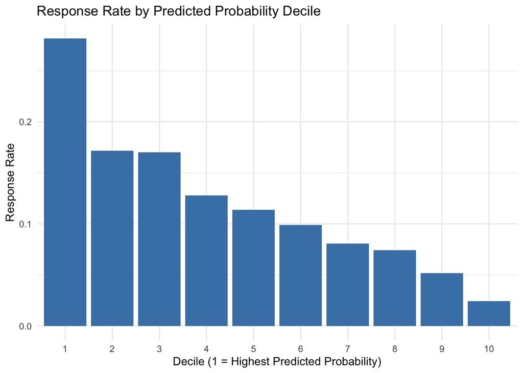

```r
library(ggplot2)

ggplot(decile_summary, aes(x = factor(decile), y = response_rate)) +
  geom_bar(stat = "identity", fill = "steelblue") +
  labs(
    title = "Response Rate by Predicted Probability Decile",
    x = "Decile (1 = Highest Predicted Probability)",
    y = "Response Rate"
  ) +
  theme_minimal()
```

```r
#The bar plot shows how the response rate drops from 28% in decile 1 to 2.5% in
#decile 10.
```

## 6. Estimate a linear regression model using “ordersize” as the dependent variable using all relevant predictor variables, namely age, sex, messages, recency, frequency, monetary, and music. Estimate this regression using only those customers who purchased the Karaoke deal.

## Hint: Use filter(buyer==1) in the dplyr package to create a dataframe limited to only those customers who purchased the Karaoke deal and use this dataframe as an input to the linear regression. Consider: why are we limiting this analysis only to these customers?

```r
library(dplyr)

buyers_only <- tuango %>%
  filter(buyer == 1)
#linear regression to predict ordersize, only for customers who purchased the Karaoke
#deal (buyer == 1).

# We filter (buyer == 1), because only those who actually made a purchase have a meaningful
# ordersize.For non-buyers, ordersize would likely be zero or missing, which would bias the regression.
ordersize_model <- lm(ordersize ~ age + sex + messages + recency + frequency + monetary + music,
                      data = buyers_only)
summary(ordersize_model)
```

```
Call:
lm(formula = ordersize ~ age + sex + messages + recency + frequency +
    monetary + music, data = buyers_only)

Residuals:
    Min      1Q  Median      3Q     Max
-3.2745 -1.0672 -0.0503  1.0285  7.8740

Coefficients:
              Estimate Std. Error t value Pr(>|t|)
(Intercept)  3.971e+00  1.605e-01  24.740   <2e-16 ***
age         -8.249e-05  2.527e-03  -0.033    0.974
sexM        -2.137e-02  7.479e-02  -0.286    0.775
messagesOn   7.217e-02  9.637e-02   0.749    0.454
recency      4.642e-04  4.748e-04   0.978    0.328
frequency    2.227e-02  1.412e-02   1.576    0.115
monetary    -8.590e-05  1.575e-04  -0.545    0.586
music1      -1.185e-01  8.525e-02  -1.390    0.165
---
Signif. codes:  0 '***' 0.001 '**' 0.01 '*' 0.05 '.' 0.1 ' ' 1

Residual standard error: 1.722 on 2491 degrees of freedom
Multiple R-squared:  0.002567,  Adjusted R-squared:  -0.0002357
F-statistic: 0.9159 on 7 and 2491 DF,  p-value: 0.4928
```

```r
confint(ordersize_model)
```

```
                    2.5 %       97.5 %
(Intercept)  3.6560413458 4.2854864861
age         -0.0050373293 0.0048723531
sexM        -0.1680277663 0.1252923806
messagesOn  -0.1167980783 0.2611480476
recency     -0.0004668828 0.0013953381
frequency   -0.0054300274 0.0499639190
monetary    -0.0003947232 0.0002229243
music1      -0.2856314660 0.0487017003
```

```r
#The coefficients estimated using linear regression are not statistically
#significant as p-value is greater than 0.05 for all.
```

## 7. Use summary(…) to examine the coefficient estimates, varimpplot(…) to assess variable importance, and pardepplot(…) the effect of each predictor. What variables seem to be practically important? Describe their effects. What does this suggest about our ability to predict the order size of those customers who responded to the deal?

```r
summary(ordersize_model)
```

```
Call:
lm(formula = ordersize ~ age + sex + messages + recency + frequency +
    monetary + music, data = buyers_only)

Residuals:
    Min      1Q  Median      3Q     Max
-3.2745 -1.0672 -0.0503  1.0285  7.8740

Coefficients:
              Estimate Std. Error t value Pr(>|t|)
(Intercept)  3.971e+00  1.605e-01  24.740   <2e-16 ***
age         -8.249e-05  2.527e-03  -0.033    0.974
sexM        -2.137e-02  7.479e-02  -0.286    0.775
messagesOn   7.217e-02  9.637e-02   0.749    0.454
recency      4.642e-04  4.748e-04   0.978    0.328
frequency    2.227e-02  1.412e-02   1.576    0.115
monetary    -8.590e-05  1.575e-04  -0.545    0.586
music1      -1.185e-01  8.525e-02  -1.390    0.165
---
Signif. codes:  0 '***' 0.001 '**' 0.01 '*' 0.05 '.' 0.1 ' ' 1

Residual standard error: 1.722 on 2491 degrees of freedom
Multiple R-squared:  0.002567,  Adjusted R-squared:  -0.0002357
F-statistic: 0.9159 on 7 and 2491 DF,  p-value: 0.4928
```

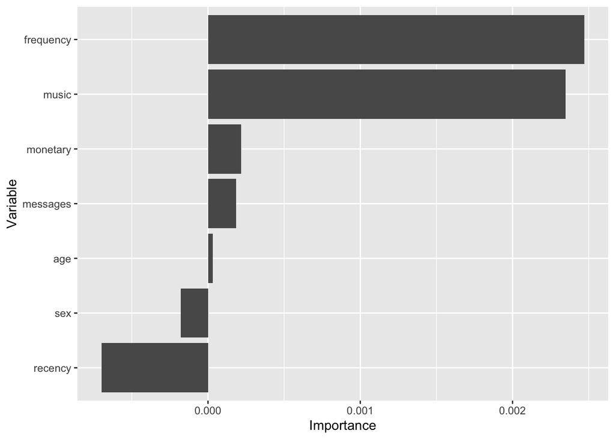

```r
varimpplot(ordersize_model, target = "ordersize", data = buyers_only)
```

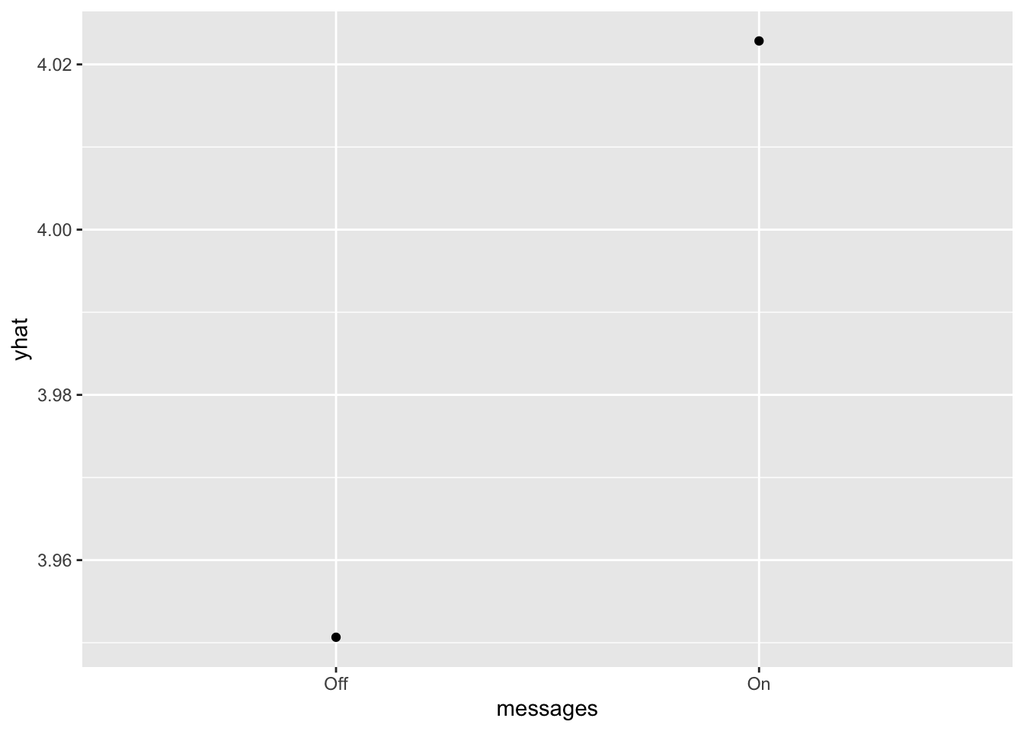

```r
pardepplot(ordersize_model, pred.var = "messages", data = buyers_only)
```

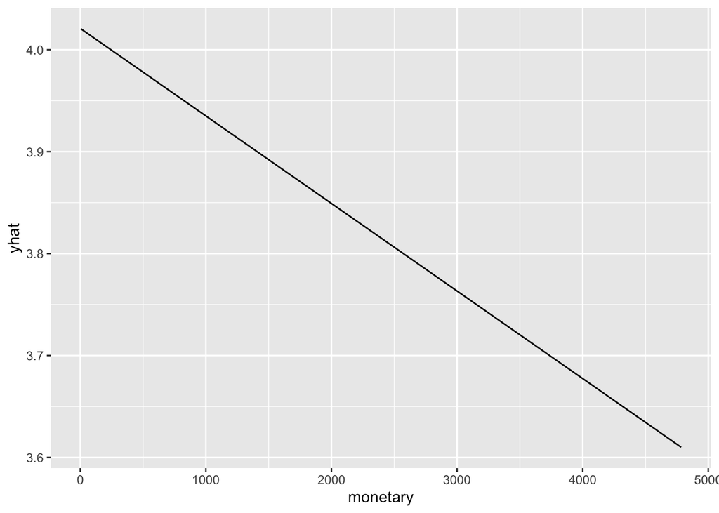

```r
pardepplot(ordersize_model, pred.var = "monetary", data = buyers_only)
```

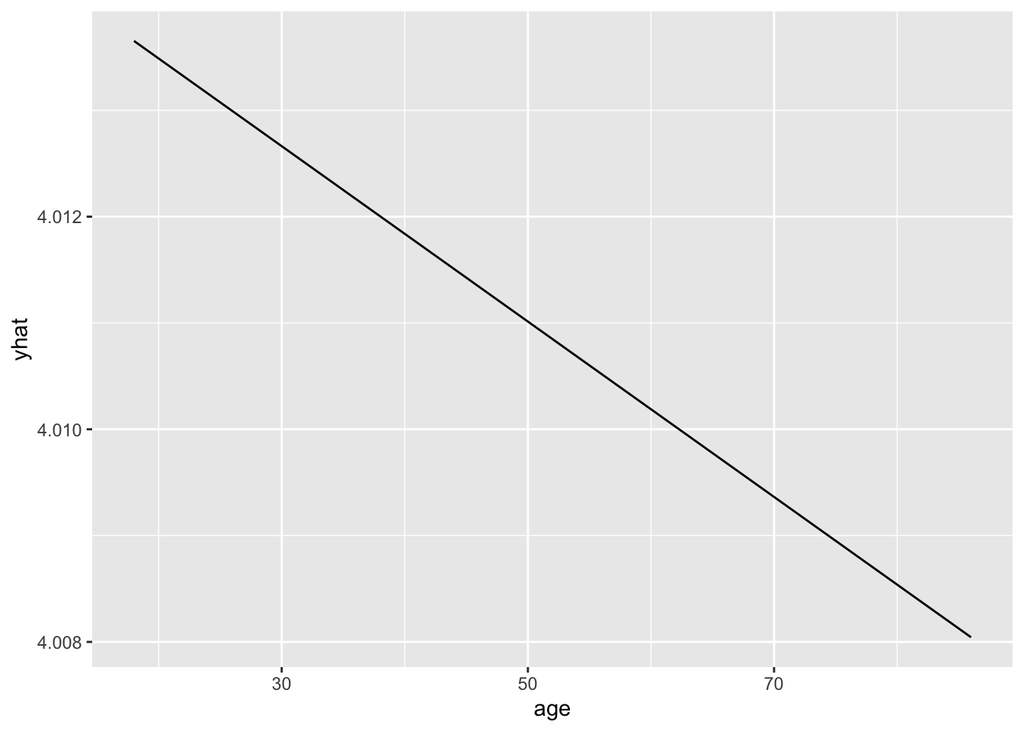

```r
pardepplot(ordersize_model, pred.var = "age", data = buyers_only)
```